# LAB 6. Text Mining

Author

Faith Okaalo

Published

February 19, 2026

## **Lab 6: Text Mining**

### Load required libraries

```r
library(dplyr)
library(ggplot2)
library(tidytext)
library(tidyr)
```

### Read in the data

```r
mtsamples <- read.csv("https://raw.githubusercontent.com/dmcable/BIOSTAT620W26/main/data/mtsamples/mtsamples.csv")

head(mtsamples)
```

```
  X
1 0
2 1
3 2
4 3
5 4
6 5
                                                                                                                                                                                                                            description
1                                                                                                                                                                      A 23-year-old white female presents with complaint of allergies.
2                                                                                                                                                                                              Consult for laparoscopic gastric bypass.
3                                                                                                                                                                                              Consult for laparoscopic gastric bypass.
4                                                                                                                                                                                                                2-D M-Mode. Doppler.
5                                                                                                                                                                                                                    2-D Echocardiogram
6  Morbid obesity.  Laparoscopic antecolic antegastric Roux-en-Y gastric bypass with EEA anastomosis.  This is a 30-year-old female, who has been overweight for many years.  She has tried many different diets, but is unsuccessful.
            medical_specialty                               sample_name
```

[output cut: 20 more lines]

### **Question 1: What specialties do we have? Are these categories related? Overlapping? Evenly distributed?**

```r
mtsamples %>%
  count(medical_specialty, sort = TRUE)
```

```
                medical_specialty    n
1                         Surgery 1103
2      Consult - History and Phy.  516
3      Cardiovascular / Pulmonary  372
4                      Orthopedic  355
5                       Radiology  273
6                General Medicine  259
7                Gastroenterology  230
8                       Neurology  223
9   SOAP / Chart / Progress Notes  166
10        Obstetrics / Gynecology  160
11                        Urology  158
12              Discharge Summary  108
13           ENT - Otolaryngology   98
14                   Neurosurgery   94
```

[output cut: 26 more lines]

There are 40 specialty categories in the dataset. They are not evenly distributed: surgery has the most transcriptions, while most of the other specialties have a few records.

### **Question 2: Tokenize and visualize the top 20 words**

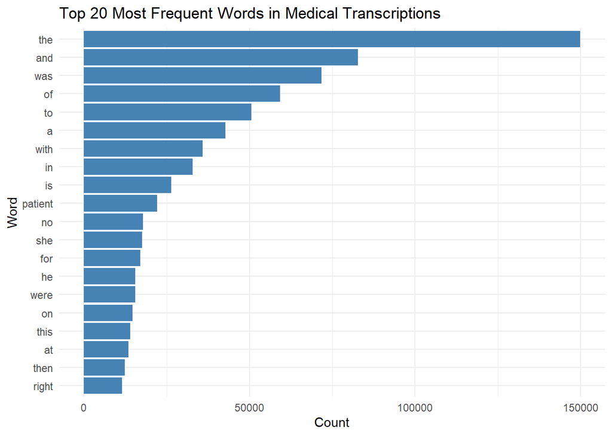

```r
tokens <- mtsamples %>%
  unnest_tokens(word, transcription)

tokens %>%
  count(word, sort = TRUE) %>%
  slice_max(n, n = 20) %>%
  ggplot(aes(x = reorder(word, n), y = n)) +
  geom_col(fill = "steelblue") +
  coord_flip() +
  labs(
    title = "Top 20 Most Frequent Words in Medical Transcriptions",
    x = "Word",
    y = "Count"
  ) +
  theme_minimal()
```

The most common words in the dataset are ’the”, “and”, “was”, “of”, “to”, “a”, “with”, “in”, “is”, “patient”, “no”, “she”, “for”, “he”, “were”, “on’,”this”, “at”, “then”, and “right.” “The” was the most common word. These are mostly stop words which is expected in English language though they do not offer any meaningful insights.

### **Question 3: Remove stop words and numbers**

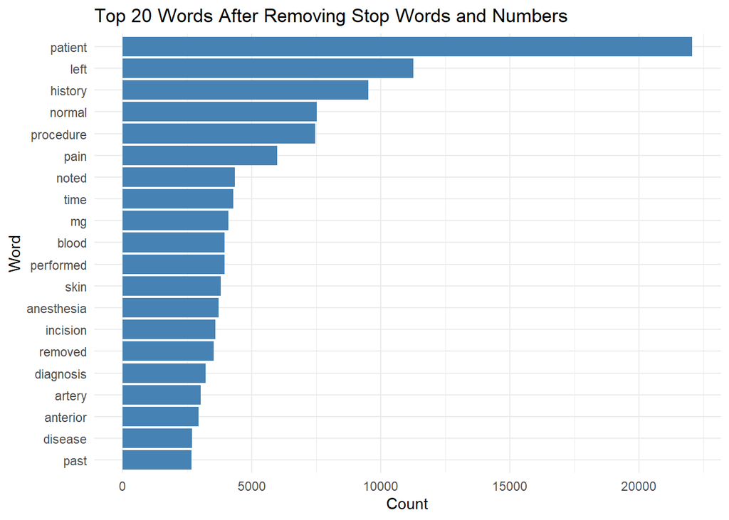

```r
tokens_clean <- tokens %>%
  anti_join(stop_words, by = "word") %>%
  filter(!grepl("^[0-9]+$", word))

tokens_clean %>%
  count(word, sort = TRUE) %>%
  slice_max(n, n = 20) %>%
  ggplot(aes(x = reorder(word, n), y = n)) +
  geom_col(fill = "steelblue") +
  coord_flip() +
  labs(
    title = "Top 20 Words After Removing Stop Words and Numbers",
    x = "Word",
    y = "Count"
  ) +
  theme_minimal()
```

After removing the stop words the stop words and numbers, the top words are now medical terms such as “patient”, “history”, “left”, “normal”, “procedure”, “pain”. These terms make sense given these are clinical transcriptions. These words now give us much better information about patients.

### **Question 4: Tokenize into bi-grams and tri-grams**

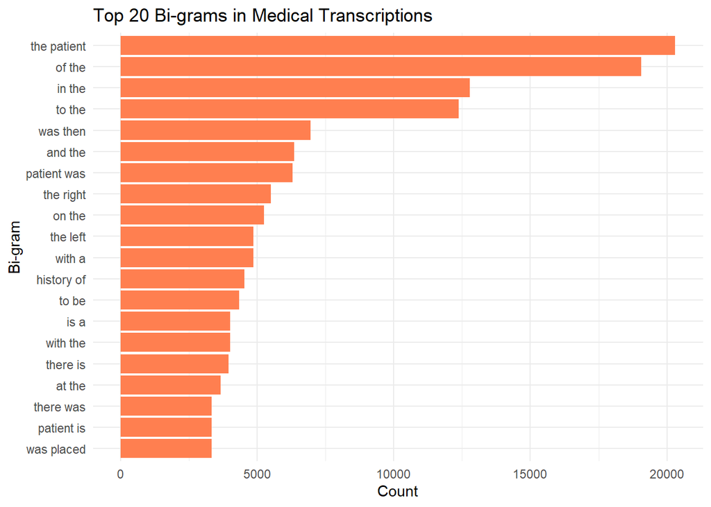

```r
bigrams <- mtsamples %>%
  unnest_ngrams(bigram, transcription, n = 2)

bigrams %>%
  count(bigram, sort = TRUE) %>%
  slice_max(n, n = 20) %>%
  ggplot(aes(x = reorder(bigram, n), y = n)) +
  geom_col(fill = "coral") +
  coord_flip() +
  labs(
    title = "Top 20 Bi-grams in Medical Transcriptions",
    x = "Bi-gram",
    y = "Count"
  ) +
  theme_minimal()
```

For the bi-grams the most frequent words were “the patient”, “of the”, “in the”, “to the” and “was then”

**Tri-grams**

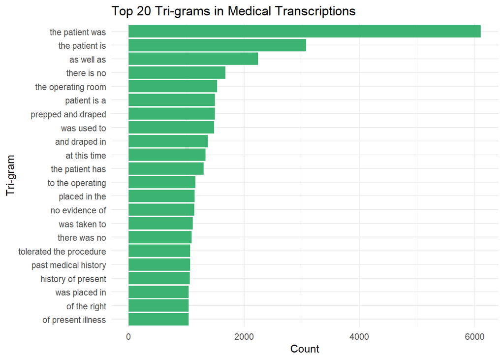

```r
trigrams <- mtsamples %>%
  unnest_ngrams(trigram, transcription, n = 3)

trigrams %>%
  count(trigram, sort = TRUE) %>%
  slice_max(n, n = 20) %>%
  ggplot(aes(x = reorder(trigram, n), y = n)) +
  geom_col(fill = "mediumseagreen") +
  coord_flip() +
  labs(
    title = "Top 20 Tri-grams in Medical Transcriptions",
    x = "Tri-gram",
    y = "Count"
  ) +
  theme_minimal()
```

For the tri-grams the most frequent words were “the patient was”, “the patient is” and “as well as”.

### Question 5: Pick a word from question 4 and count how many words appear before or after it.

**Words before it**

```r
bigrams_separated <- bigrams %>%
  separate(bigram, into = c("word1", "word2"), sep = " ")

before_pain <- bigrams_separated %>%
  filter(word2 == "pain") %>%
  count(word1, sort = TRUE) %>%
  slice_max(n, n = 10)

print("Words appearing BEFORE 'pain':")
```

```
[1] "Words appearing BEFORE 'pain':"
```

```r
before_pain
```

```
       word1   n
1      chest 707
2       back 561
3  abdominal 461
4        the 361
5       neck 218
6        for 178
7         of 163
8        and 130
9        his 127
10       her 115
```

The words that often appear before the word pain include “chest”, “back”, “abdominal”, “the”, “neck”, “for”, “of”, “and”, “his”, and “her”.

**Words that appear after the word pain**

```r
after_pain <- bigrams_separated %>%
  filter(word1 == "pain") %>%
  count(word2, sort = TRUE) %>%
  slice_max(n, n = 10)

print("Words appearing AFTER 'pain':")
```

```
[1] "Words appearing AFTER 'pain':"
```

```r
after_pain
```

```
         word2   n
1          and 500
2           in 323
3           or 255
4         with 231
5           is 199
6           he 191
7          the 185
8          she 165
9           no 147
10 medications 103
```

The top ten words that often appear after pain include “and”, “in”, “or”, “with”, “is”, “he”, “the”, “she”, “no”, and “medications”.

### Question 6: Words that are often used in each of the specialties.

```r
specialty_words <- mtsamples %>%
  unnest_tokens(word, transcription) %>%
  anti_join(stop_words, by = "word") %>%
  filter(!grepl("^[0-9]+$", word)) %>%
  count(medical_specialty, word, sort = TRUE) %>%
  group_by(medical_specialty) %>%
  top_n(5, n) %>%
  arrange(medical_specialty, desc(n))

specialty_words
```

```
# A tibble: 210 × 3
# Groups:   medical_specialty [40]
   medical_specialty       word          n
   <chr>                   <chr>     <int>
 1 " Allergy / Immunology" history      38
 2 " Allergy / Immunology" noted        23
 3 " Allergy / Immunology" patient      22
 4 " Allergy / Immunology" allergies    21
 5 " Allergy / Immunology" nasal        13
 6 " Allergy / Immunology" past         13
 7 " Autopsy"              left         83
 8 " Autopsy"              inch         59
 9 " Autopsy"              neck         55
10 " Autopsy"              anterior     47
# ℹ 200 more rows
```

The terms *“patient”* and *“history”* appeared among the top-ranked words in the majority of specialties (e.g., Surgery: patient = 4,855; Consult – History & Physical: history = 2,820). Additional common terms such as *“normal,” “left”, “pain,”* and *“procedure”* were observed across multiple clinical domains, such as Autopsy, Chiropractic, Dentistry, and Dermatology. Procedural fields such as Surgery, Orthopedics, Neurosurgery, and Urology had high frequencies of intervention-specific terminology, including *“procedure,” “incision,”* and *“anesthesia.”* Organ-system specialties used words reflective of their clinical focus, such as *“thyroid”* and *“gland”* in Endocrinology, *“colon”* in Gastroenterology, *“renal”* and *“kidney”* in Nephrology, and *“eye”* and *“anterior chamber”* in Ophthalmology. The Dermatology and Pathology specialty, frequently included quantitative descriptors such as *“cm,” “mass,”* and *“tumor.”* Specialties such as Psychiatry/Psychology, Hospice/Palliative Care, and Pediatrics had words such as *“mother,” “daughter,”* and *“family.”*

### Question 7: Rate of pain across specialties.

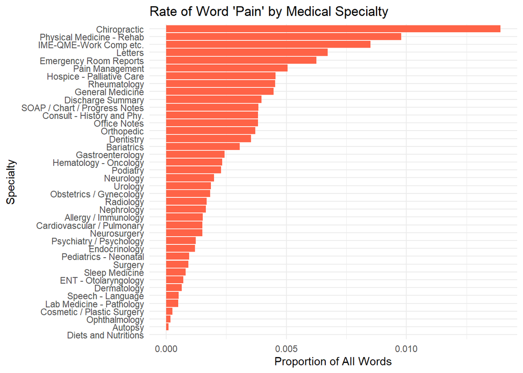

```r
mtsamples %>%
  unnest_tokens(word, transcription) %>%
  group_by(medical_specialty) %>%
  summarise(
    total_words = n(),
    pain_count = sum(word == "pain")
  ) %>%
  mutate(pain_rate = pain_count / total_words) %>%
  filter(total_words > 500) %>%  # keep only specialties with enough data
  arrange(desc(pain_rate)) %>%
  ggplot(aes(x = reorder(medical_specialty, pain_rate), y = pain_rate)) +
  geom_col(fill = "tomato") +
  coord_flip() +
  labs(
    title = "Rate of Word 'Pain' by Medical Specialty",
    x = "Specialty",
    y = "Proportion of All Words"
  ) +
  theme_minimal()
```